# Assignment 5 - Factors and data input-output

## Exercise 4: Visualization design

For this exercise, I am going to use a plot I made back in assignment 1. I looked at the relationship between GDP and life expectancy for the entire dataset, and see if there was a certain level of wealth at which the associated gains in life expectancy became muted. Without knowledge of `dplyr` and `ggplot2`, the process was more difficult than it could have been and the graph doesn’t look as nice as what I can do now.

Below on the left is my old graph done wth base R plotting, and on the right is my new version of the graph made with `ggplot2`.

- **Note:** *this code is written in the order of (1. store new graph to object, 2. make old graph, 3. display new graph from object) because my old base R plot can’t be saved to an object within an Rmd file. If I want the old one on the left and the new one on the right within a two-column display, the right panel will be filled entirely with my new graph’s code if I try to code it directly after the old graph. As it is, the call to the new.gr object is still in that right panel, but it allows enough space for the graph to be displayed under it. If my old graph were a ggplot2 plot, this ugly code could be avoided by saving them both as objects and calling them in only two lines.*

```r
new.gr <- gapminder %>%
            ggplot(aes(x = gdpPercap,
                       y = lifeExp)) +
              geom_point( alpha=0.2, #make points transparent
                          size=2 ) + #make them a little larger
              geom_smooth( method = "lm", #linear model for the smoothed line
                           formula = y ~ log(x)) + #formula for the line- this actually makes a log relationship which is what I want, not linear
              scale_x_continuous(lim = c(0,50000), #limit the x-axis towards the low-GDP section in which the asymptote is approached
                                 labels = scales::dollar_format() ) + #put x axis labels in dollar format
              ylim(c(0,90)) +
              labs( x = "GDP per capita, ($ US, inflation-adjusted)", #make nice x axis label
                    y = "Life expectancy", #nice y axis label
                    title = "Life expectancy increases correlated to rising GDP seem to show diminishing returns",
                    caption = "Data source: R gapminder package, http://www.gapminder.org/data") + #tell the user what I'm trying to show
              theme_bw() + #use the nicer black and white theme
              theme(plot.title = element_text(size = 10, #change title size
                                              face = "bold"), #make title bold
                    plot.caption = element_text(size = 7), #make caption text smaller
                    axis.title = element_text( face = "bold") ) #make axis labels bold
```

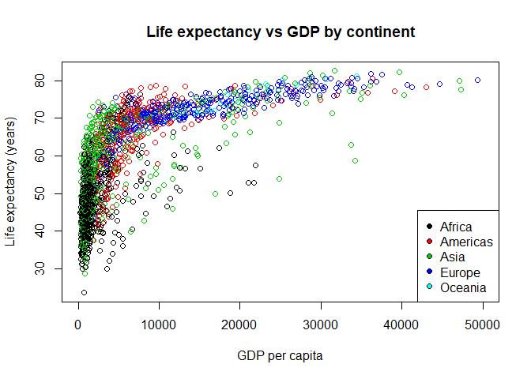

```r
#shorten name of gapminder dataset (lazy!)
gm <- gapminder

#need labels for legend
leg.labels <- levels(as.factor(gm$continent))

#create the plot with a legend
{ # these brackets are so the legend is written to the same image as the plot

  #create plot
  plot(gm$gdpPercap, #x variable
       gm$lifeExp,  #y variable
       xlim=c(0,50000), #x axis limits
       ylab="Life expectancy (years)",
       xlab="GDP per capita",
       main="Life expectancy vs GDP by continent",
       col=as.factor(gm$continent)) #colour points by continent

  #create legend in bottom right
  legend("bottomright", pch=21, pt.bg=1:length(leg.labels),
       legend=leg.labels )

} #end brackets to keep it together
```

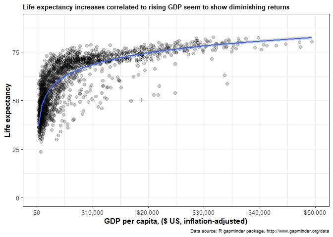

```r
new.gr #display the new graph
```

#### A comparison of the two graphs:

- The quality of the image is higher in the new graph; it looks more modern and sharp.
- In my original graph, I didn’t really like how the hollow markers looked. but I couldn’t use solid filled points because there was too much overlap In the new graph, the use of the *alpha* argument allowed points to not overshadow eachother as much.
- Because I didn’t colour points by continent in the new graph, I didn’t need a legend at all. If I did need a legend, then `ggplot2` would have done it for me automatically, saving the steps of manually creating it in my original code.

#### Things I thought about doing differently in the new graph but chose not to:

- I considered putting a log x-axis with `scale_x_log10()`. It would declutter points and spread them out more, but I decided not to as the point I was originally trying to address was whether there is a certain GDP level that life expectancy gains are muted at. The linear x-axis shows the levelling of the trend better, and also allows easier reading of the GDP values.
- I considered to turn off the x-axis limits, but the points past $50000 (all from Kuwait) are a distraction to the trend I am trying to highlight. The Kuwait points are interesting but they are a unique and separate story.

## Exercise 5: Writing figures to file

In order to save my plot in a reproducible way, I will use the `here` package to do so. I will save the last plot I made in exercise 4 by not specifying the `plot` argument within `ggsave`.

```r
#set file saving location with here::here
file.loc.ex5plot1 <- here::here("Assignments", "Assignment_05", "ex5_plot-GDP_x_lifeExp.png")

#because I am not specifying the plot argument, this will save the last plot I made
ggsave(filename = file.loc.ex5plot1,
       device = "png")
```

Sometimes, though, I won’t want to save the last plot I made and will need to use the `plot` argument of `ggsave`, as in the example below where I call in the plot object I made back in exercise 3. Just to mix it up, I will save this plot in pdf format (vector) instead of png format (raster), and I will save one copy in wide format and one in narrow format.

```r
#save the exercise 3 plot using here::here and ggsave(), make it wider
file.loc.ex5plot2_wide <- here::here("Assignments", "Assignment_05", "ex5_plot-lifeExp_CV_Asia-wide.pdf")
ggsave(filename = file.loc.ex5plot2_wide,
       plot = lifeExp_plot,
       device = "pdf",
       width = 14,
       height = 6)

#save the exercise 3 plot but make it tall and narrow
file.loc.ex5plot2_tall <- here::here("Assignments", "Assignment_05", "ex5_plot-lifeExp_CV_Asia-tall.pdf")
ggsave(filename = file.loc.ex5plot2_tall,
       plot = lifeExp_plot,
       device = "pdf",
       height = 12,
       width = 6)
```

Now I can embed the files in my markdown report via links. Here is the wide one and here is the tall and narrow one.